# Budapest Property Market: Tools for Exploratory Data Analysis

Benoît Guillaud

15 June 2017

# Abstract

This is the first in a serie of three papers to illustrate the use of simple R tools for the analysis of a city’s Real Property market. We focus here on data preparation, descriptive statistics, and understand the dataset ahead of applying Machine Learning tools. The following papers deal with predictive modelling and optimisation.

We will provide an overview of sales and rental market, and identify areas with the best investment potential.

Along the way, we will learn how to:

- Compute statistics - Group, create new variables and summarize data with `dplyr::`
- Visualize summary statistics - Box plots and violin plots with `ggplot2::` and `plotly::`
- Test hypotheses - Scatter plots and testing with `stats::cor.test()`
- Identify confounders - Plot correlograms with `corrgram::` and mosaics with `vcd::` for continusous and categorical variables, respectively.
- Identify class imbalances - Density plots with `ggplot2::`
- Identify missing values with `VIM::`
- Identify “near-zero variance” variables with `caret::`

# Present, Load and Prepare the dataset

The goal of this section is to illustrate a simple, general and systematic process to start with a dataset.

## Origin of the data

The datasets analysed were scraped from www.ingatlan.com, a popular platform in Hungary for property listings, using a bespoke script that leverages the powerful Python library “BeautifulSoup”.

The following assumptions are made when carrying out the search: - Limit the search to 3 inner-city districts (V. VI. and VII. kerület) - Limit the search to brickwork building (the vast majority in these districts) - Set “tenancy for sale” = NO, as I don’t understand it

The resulting search url are:

- Sales (elado): http://ingatlan.com/listar/elado+lakas+nem-berleti-jog+tegla-epitesu-lakas+budapest+v-vi-vii-ker
- Rentals (kiado): http://ingatlan.com/listar/kiado+lakas+nem-berleti-jog+tegla-epitesu-lakas+budapest+v-vi-vii-ker

## Features

The following features are extracted from the listings:

| Feature | Description | Type |
| --- | --- | --- |
| listing | Number of the listing | ID |
| price | Asking price in million Forint (HUF) | Float |
| area | Flat floor area (mezzanine NOT included) | Integer |
| rooms | Number of rooms | String |
| fullrooms | Number of full rooms | Integer |
| halfrooms | Number of half rooms | Integer |
| district | District wehre the property is located | String |
| varos | Administrative division inside the district | String |
| condition | Condition of the property | String |
| floor | Floor | Integer |
| storeys | Number of storeys in the building | Integer |
| lift | Presence of an elevator | Boolean |
| heating | Type of heating | String |
| view | Opening to the street or internal yard etc. | String |
| lat | Latitude of the property | Float |
| long | Longitude of the property | Float |
| orient | Orientation of the windows | String |
| parking | Options for parking, if any | String |
| balcony | Whether there is a balcony or not | Boolean |
| aircon | Whether these is air conditioning | Boolean |
| ceiling | Ceiling height | Boolean |
| utility | Utility level as classified by ingatlan.com | String |
| bathtoil | Whether bathroom and toilets are together | String |
| garcess | Whether there is garden access | Boolean |

Features not collected include the street, as they usually span across long distances in Budapest.

Later in the analysis, the selling and rental rental prices are expressed in mFt(/year), while the price-per-square-meter are expressed in kFt/m2(/year).

## Load and clean the data

This script loads the raw data as they were collected, then prepare them into 2 tidy datasets:

- “elado” contains all sales data
- “kiado” contains all rental data

The processing typically involves cleaning, recoding, feature engineering and feature selection for further analysis.

```r
# Load the data
elado <- read.csv("./data/extraction_elado_2017_03_16.txt",
                  fileEncoding="UTF-8-BOM", header=TRUE, sep=";")
kiado <- read.csv("./data/extraction_kiado_2017_03_16.txt",
                  fileEncoding="UTF-8-BOM", header=TRUE, sep=";")

# Clean and recode the variables
elado <- PrepareData(elado)
kiado <- PrepareData(kiado)

# Create new variable ppsm and rpsm from "price"
elado <- dplyr::mutate(elado, ppsm = price*1000/area)    # kFt/m2
kiado <- dplyr::mutate(kiado,
                       rent = price*12/1000,             # mFt/year
                       rpsm = price*12/area)             # kFt/m2/year


# select the features of interest
elado <- dplyr::select(elado, price, ppsm, area, halfrooms, fullrooms, varos, district,
                       lift, floor, balcony, view, condition, heating, aircon, orient)
kiado <- dplyr::select(kiado, rent, rpsm, area, halfrooms, fullrooms, varos, district,
                       lift, floor, balcony, view, condition, heating, aircon, orient)
```

# Descriptive Analytics

In this section, we focus on building simple statistics to answer questions about the property market, for instance variation of the price-per-square-meter (`ppsm` and `rpsm`) or the annual return on investment (`anr`) against other variables.

## Variations `district` to `district`

The following tables report the median value and standard deviation of `ppsm` and `rpsm` in each district. The results are expressed in kFt/m2 (/year).

```r
# calculate median and standard deviations
districts.el <- dplyr::group_by(elado, district)
districts.ki <- dplyr::group_by(kiado, district)

dplyr::summarise(districts.el,
                 total.count = n(),
                 median.ppsm = round(median(ppsm, na.rm = TRUE), 1), # unit: kFt/m2
                 sd.ppsm = round(sd(ppsm,na.rm = TRUE), 1))          # unit: kFt/m2
```

```
## # A tibble: 3 × 4
##   district total.count median.ppsm sd.ppsm
##     <fctr>       <int>       <dbl>   <dbl>
## 1   5. ker        3022       862.3  9992.9
## 2   6. ker        4257       631.1   233.6
## 3   7. ker        4341       514.8   158.8
```

```r
dplyr::summarise(districts.ki,
                 total.count = n(),
                 median.rpsm = round(median(rpsm, na.rm = TRUE), 1), # unit: kFt/m2/year
                 sd.rpsm = round(sd(rpsm,na.rm = TRUE), 1))          # unit: kFt/m2/year
```

```
## # A tibble: 3 × 4
##   district total.count median.rpsm sd.rpsm
##     <fctr>       <int>       <dbl>   <dbl>
## 1   5. ker        1524        44.4    43.1
## 2   6. ker        1373        39.0    35.4
## 3   7. ker         900        35.6    14.2
```

As expected, the highest prices per square meter are in the 5th district, which is most central. This is also where the standard deviation is highest, probably driven by a few outliers.

## Variations `varos` to `varos` (tables)

Let’s now compile a (more detailed) table for each `varos`, with not only `ppsm` and `rpsm` but also `anr`. Note that we use here the pipeline operator `%>%` for a more compact syntax. The annual return is expressed in percent.

```r
# calculate median and standard deviations
elado.by_varos <- na.omit(elado) %>%
  dplyr::group_by(district, varos) %>%
  dplyr::summarise(n = n(),
                   med.ppsm = round(median(ppsm)*1000, 1), # unit: kFt/m2
                   sd.ppsm = round(sd(ppsm)*1000, 1))      # unit: kFt/m2

kiado.by_varos <- na.omit(kiado) %>%
  dplyr::group_by(district, varos) %>%
  dplyr::summarise(n = n(),
                   med.rpsm = round(median(rpsm)*1000, 1), # unit: kFt/m2/year
                   sd.rpsm = round(sd(rpsm)*1000, 1))      # unit: kFt/m2/year

# combine the two tables
ela.kia.by_varos <- dplyr::inner_join(elado.by_varos, kiado.by_varos, by=c("district","varos"))

# calculate annual return and its standard deviation
ela.kia.by_varos <- ela.kia.by_varos %>%
  dplyr::mutate(med.anr = round(med.rpsm / med.ppsm * 100, 1), # annual return in %
                sd.anr = round(med.anr * sqrt((sd.ppsm/med.ppsm)^2 +(sd.rpsm/med.rpsm)^2), 1)) # uncertainty in abs percent

# display table
print(ela.kia.by_varos[,c(1,2,4,7,9,10)])
```

```
## Source: local data frame [9 x 6]
## Groups: district [3]
##
##   district                              varos med.ppsm med.rpsm med.anr sd.anr
##     <fctr>                              <chr>    <dbl>    <dbl>   <dbl>  <dbl>
## 1   5. ker                           Belváros 967391.3  46400.0     4.8    2.4
## 2   5. ker                         Lipótváros 954023.0  49461.2     5.2    3.4
## 3   6. ker                   Belso-Terézváros 894375.0  42046.0     4.7    2.7
## 4   6. ker                   Külso-Terézváros 653571.4  38814.4     5.9    3.3
## 5   6. ker Külso-Terézváros  Diplomatanegyed 757877.2  40000.0     5.3    2.5
## 6   7. ker                Belso-Erzsébetváros 664098.4  45000.0     6.8    3.0
## 7   7. ker              Középso-Erzsébetváros 537939.9  30483.5     5.7    1.8
## 8   7. ker                Külso-Erzsébetváros 538055.7  34358.8     6.4    2.0
## 9   7. ker   Külso-Erzsébetváros  Ligetváros 461538.5  30476.2     6.6    NaN
```

Based on median price per square meter, the best investment opportunities are in “Belso-Erzsébetváros” inside the 7th district, where `med.anr = 6.8 %`. The variable `sd.anr` provides an estimate of uncertainty: one can expect annual return in the range `6.8 +/- 3.0 %`. The large uncertainty confirms the obvious idea that variables other than location contribute to the selling and rental value of a flat.

Note that the uncertainty calculation assumes that `ppsm` and `rpsm` are Normally distributed, which is not strictly true as both distributions are skewed.

## Variations `varos` to `varos` (violin plots)

Let’s now deliver the same information, but in a visual way using violin plots, which give at a glance the the probability density fuction of the data.

The plots are inpired by http://www.sthda.com/english/wiki/ggplot2-violin-plot-quick-start-guide-r-software-and-data-visualization.

Firstly, the selling price:

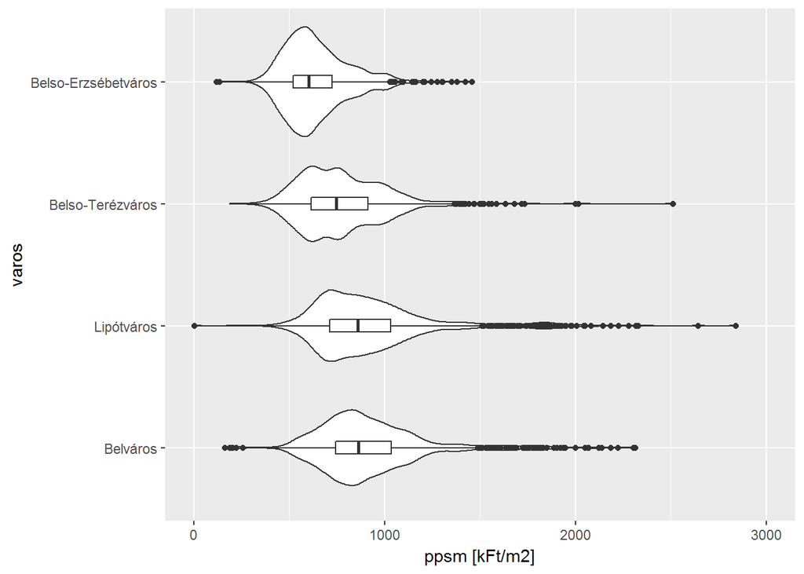

```r
# basic violin plot
p <- ggplot2::ggplot(data = elado, aes(x = varos, y = ppsm)) +
  geom_violin(trim=TRUE)

# select items to display
p <- p + scale_x_discrete(limits=c("Belváros", "Lipótváros",
                                   "Belso-Terézváros","Belso-Erzsébetváros"))

# scale the axis
p <- p + scale_y_continuous(limits = c(0, 3000)) # deletes the data
#p <- p + coord_cartesian(xlim = c(0,2)) # centers the plot

# add labels
p <- p + ylab("ppsm [kFt/m2]")
# Rotate the  plot
p <- p + coord_flip()

# Add summary statistics
p <- p + stat_summary(fun.y=median, geom="point", size=2, color="red")
p <- p + geom_boxplot(width=0.1)

print(p)
```

Similarly for rental prices, with an interactive plot (thanks to the package `plotly::`):

[interactive chart not shown]

## Variations with `area`

The purpose of this paragraph is to understand if the price-per-square-meter drops for larger flats. This is an important questions for investor who might wonder if they are better off buying one large flat or 2 smaller ones. We are essentially asking if the two variables `ppsm` and `area` are correlated. Let’s first plot them, then answer the question more formally through Hypothesis testing.

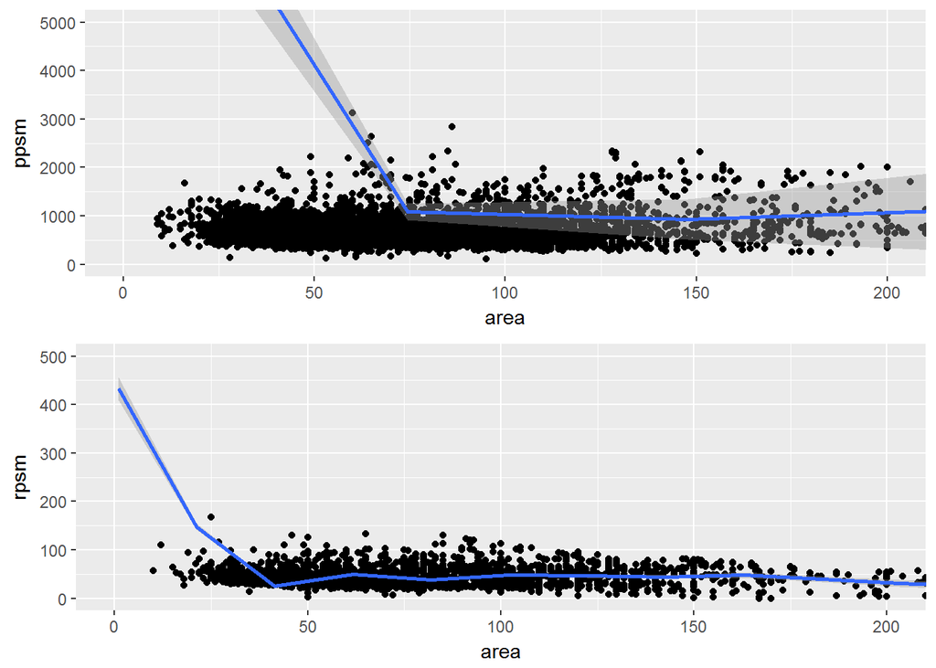

```r
p1 <- ggplot2::ggplot(data = elado, aes(x = area, y = ppsm)) +
        geom_point() +
        #scale_x_continuous(limits = c(0,200)) +
        #scale_y_continuous(limits = c(0,3000)) +
        coord_cartesian(xlim = c(0, 200), ylim = c(0,5000)) +
        geom_smooth()

p2 <- ggplot2::ggplot(data = kiado, aes(x = area, y = rpsm)) +
        geom_point() +
        #scale_x_continuous(limits = c(0,200)) +
        #scale_y_continuous(limits = c(0,200)) +
        coord_cartesian(xlim = c(0, 200), ylim = c(0,500)) +
        geom_smooth()

gridExtra::grid.arrange(p1, p2)
```

```r
with(data = elado, cor.test(area, ppsm), method = "pearson")
```

```
##
##  Pearson's product-moment correlation
##
## data:  area and ppsm
## t = -0.89359, df = 11618, p-value = 0.3716
## alternative hypothesis: true correlation is not equal to 0
## 95 percent confidence interval:
##  -0.026468525  0.009893946
## sample estimates:
##         cor
## -0.00829003
```

```r
with(data = kiado, cor.test(area, rpsm), method = "pearson")
```

```
##
##  Pearson's product-moment correlation
##
## data:  area and rpsm
## t = -4.5417, df = 3795, p-value = 5.752e-06
## alternative hypothesis: true correlation is not equal to 0
## 95 percent confidence interval:
##  -0.10508915 -0.04181431
## sample estimates:
##         cor
## -0.07352572
```

### Variation with `lift`

Here is a simple question: “on average, is the property value higher when there is an elevator in the building?”. One can summarize data with the dplyr package but a visual solution using box plots is preferred.

```r
# elado
p1 <- ggplot2::ggplot(data = dplyr::filter(elado, varos == "Belso-Terézváros"),
                      aes(x = lift, y = ppsm)) +
          geom_boxplot() +
          coord_cartesian(ylim = c(0, 1200)) +
          scale_y_continuous(breaks = seq(0, 1200, 200)) +
          ylab("PPSM in kFt/m2")

plotly::ggplotly(p1)
```

[interactive chart not shown]

In the varos “Belso-Terézváros”, flats with a lift have a price per square meter 22% higher than without a lift.

The result is intuitively right, but one should always be careful not to draw incorrect conclusions from such simple analyses because the variable `lift` may be strongly coupled with other variables, which would “confound”" the result.

For instance, old buildings in the city centre are very expensive because of the location is great, but they are also less likely to have elevators, so a simple analysis could show that flats with a elevator are less expensive.

# Data exploration for Machine Learning

In the section, the goal is to gain insights into the dataset ahead of applying Machine Learning tools for predictive modelling

## Identify confounders

It is usually a good idea to understand how the variables in a dataset are correlated, in order NOT to make incorrect inferences. At the same time, if the purpose of the model is to make predictions (as opposed to making inferences, or hypothesis tests), then checking for confounders is as not important.

A good discussion on the topic is at https://www.researchgate.net/post/How_do_I_find_confounding_variables.

Use the awesone graph called a “Correlogram”" to vizualise pairwise correlations of continuous variables:

```r
# select a few continuous variables
elado.cont <- dplyr::select(elado, price, area, fullrooms, halfrooms)

# covariances matrix (not very interpretable)
cov(elado.cont)
```

```
##                  price        area  fullrooms  halfrooms
## price     2290.7654207 1704.049446 39.2137489 -0.0710283
## area      1704.0494459 6481.825923 97.0840224  2.3453360
## fullrooms   39.2137489   97.084022  3.4259892 -0.1211854
## halfrooms   -0.0710283    2.345336 -0.1211854  0.4543788
```

```r
# correlation coefficients [see also "R in Action"]
cor(elado.cont, y=NULL, use="pairwise.complete.obs", method=c("pearson","kendall","spearman"))
```

```
##                  price       area   fullrooms    halfrooms
## price      1.000000000 0.44222491  0.44264448 -0.002201568
## area       0.442224909 1.00000000  0.65148749  0.043216280
## fullrooms  0.442644484 0.65148749  1.00000000 -0.097128833
## halfrooms -0.002201568 0.04321628 -0.09712883  1.000000000
```

```r
# testing correlations for significance (only 2 variables at a time)
with(data = elado.cont, cor.test(price, area, alternative="two.side", method="pearson"))
```

```
##
##  Pearson's product-moment correlation
##
## data:  price and area
## t = 53.145, df = 11618, p-value < 2.2e-16
## alternative hypothesis: true correlation is not equal to 0
## 95 percent confidence interval:
##  0.4274797 0.4567349
## sample estimates:
##       cor
## 0.4422249
```

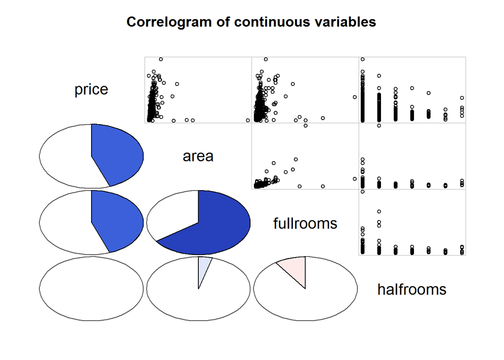

```r
# visualize correlations with a correlogram
corrgram::corrgram(elado.cont,
                   order=FALSE,
                   lower.panel = panel.pie,
                   upper.panel = panel.pts,
                   text.panel = panel.txt,
                   main = "Correlogram of continuous variables")
```

It turns out that the number of full rooms is strongly correlated with the area. No surprise. The number of halfrooms is only slightly correlated with the area, whilst the price is not correlated at all with the number of halfrooms

Use the awesome mosaic plots to look at the categorical variables:

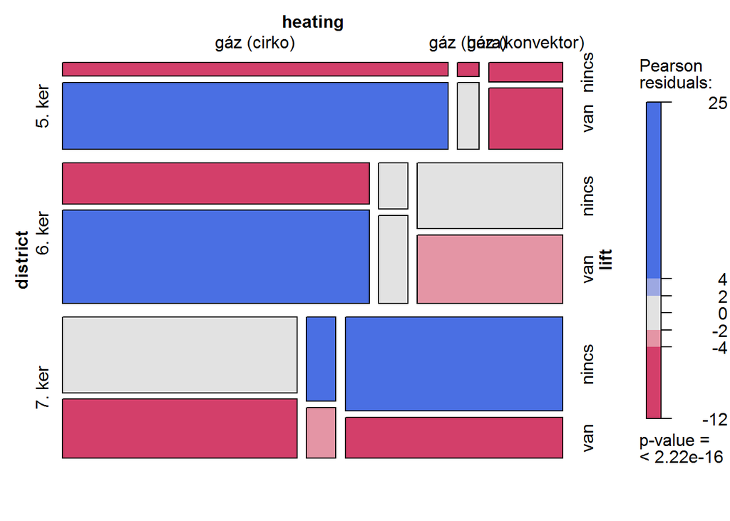

```r
# select a few categorical variables
elado.cat <- elado %>%
  dplyr::filter(heating == "gáz (cirko)" |
                heating == "gáz (konvektor)" |
                heating == "gáz (héra)") %>%
  droplevels()

vcd::mosaic(~district+heating+lift,
            elado.cat,
            shade = TRUE, legend = TRUE)
```

## Identify class imbalances

A simple bar plot for the various variables will help identify severe class imbalance and recode some of the categorical variables as required.

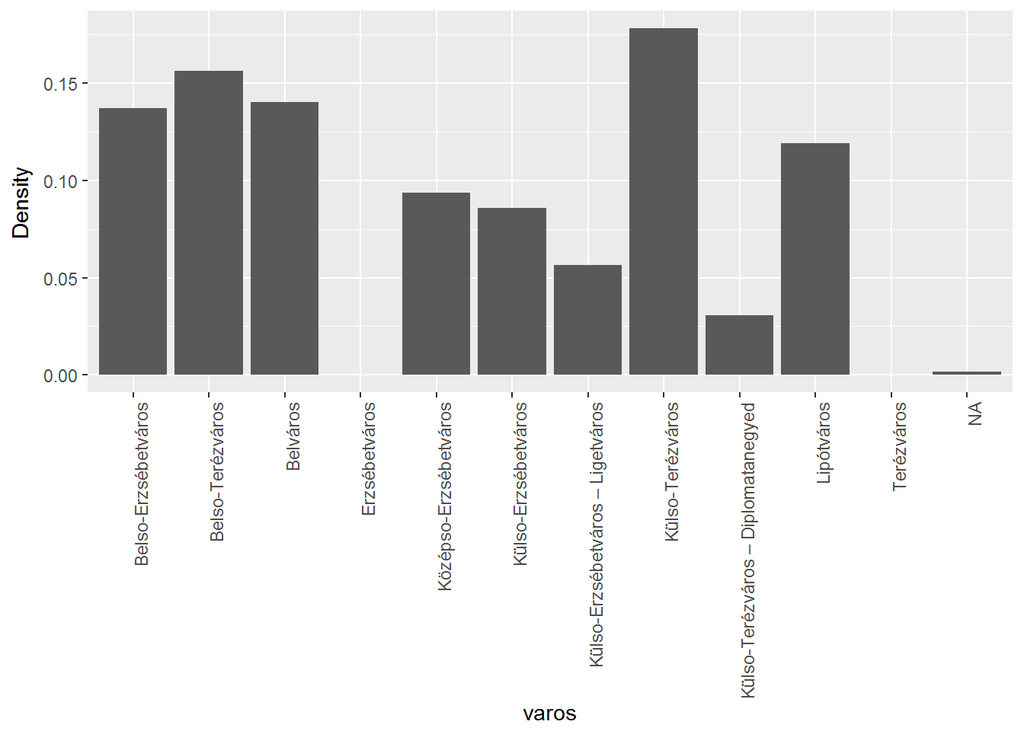

```r
ggplot2::ggplot(data = elado, aes(x = varos)) +
  geom_bar(aes(y = (..count..)/sum(..count..))) +
  ylab("Density") +
  theme(axis.text.x = element_text(angle = 90, hjust = 1))
```

## Identify missing values

Sometimes the dataset can be sparse. A simple bar chart will help see which variables have many missing values. Imputation techniques can deal effectively with missing values in order to increase the number of examples available for training.

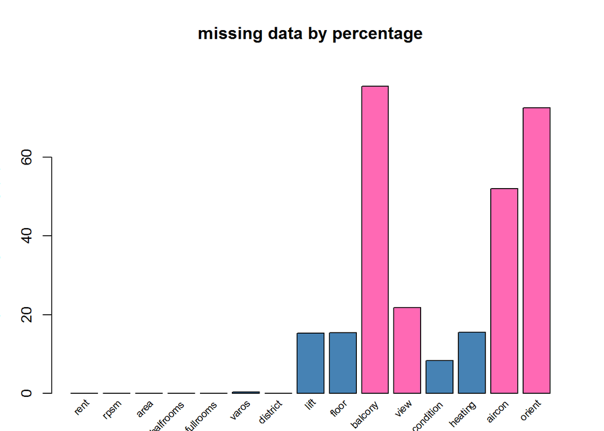

```r
PlotMissingPercentages(kiado, 'hotpink', 20)
```

Similarly, it can be interesting to understand in which spectrum of the data are the missing values.

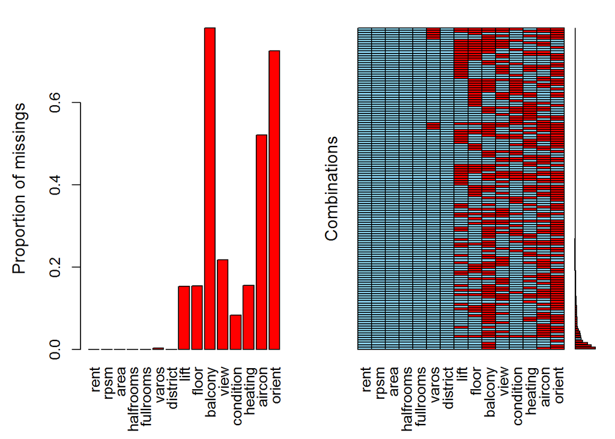

```r
VIM::aggr(kiado, plot = TRUE, bars = TRUE, combined = FALSE)
```

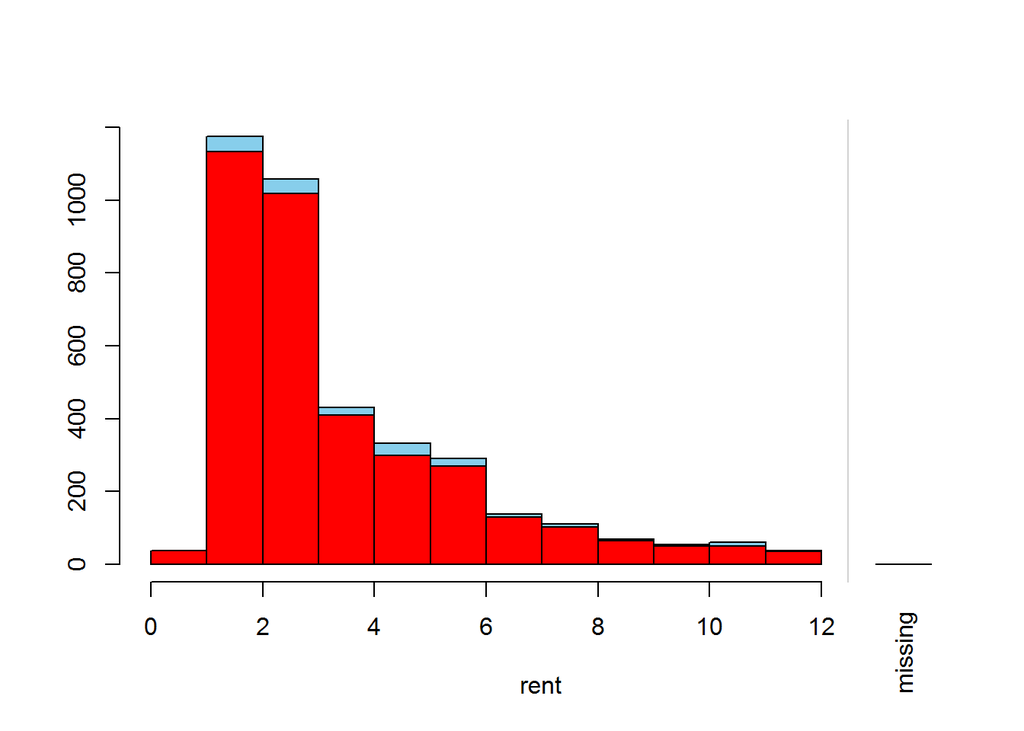

```r
VIM::histMiss(kiado, pos = 1)
```

## Near-zero variance

Identify variables with near-zero variance to de-clutter the analysis, by removing variables with near-zero variance.

```r
nzv <- caret::nearZeroVar(elado, saveMetrics= TRUE)
print(nzv)
```

```
##           freqRatio percentUnique zeroVar   nzv
## price      1.076923   13.60585198   FALSE FALSE
## ppsm       1.444444   46.13597246   FALSE FALSE
## area       1.035533    2.40103270   FALSE FALSE
## halfrooms  2.220154    0.06024096   FALSE FALSE
## fullrooms  1.401520    0.21514630   FALSE FALSE
## varos      1.139791    0.09466437   FALSE FALSE
## district   1.019732    0.02581756   FALSE FALSE
## lift       1.978144    0.01721170   FALSE FALSE
## floor      1.002834    0.08605852   FALSE FALSE
## balcony   14.367347    2.34079174   FALSE FALSE
## view       1.901448    0.03442341   FALSE FALSE
## condition  1.020813    0.06024096   FALSE FALSE
## heating    1.814086    0.10327022   FALSE FALSE
## aircon     1.015979    0.01721170   FALSE FALSE
## orient     1.169062    0.06884682   FALSE FALSE
```